# Project: The Movies Dataset

- Introduction
- Data Wrangling
- Exploratory Data Analysis
- Conclusions

## Introduction

I selected the movies dataset available on [Kaggle](https://www.kaggle.com/rounakbanik/the-movies-dataset)

> The dataset consists of ~10,000 movies released on or before July 2017. Data points include cast, crew, plot keywords, budget, revenue, posters, release dates, languages, production companies, countries, TMDB vote counts and vote averages. This dataset also has files containing 26 million ratings from 270,000 users for all 45,000 movies. Ratings are on a scale of 1-5 and have been obtained from the official GroupLens website.

With the movie dataset, I plan on answering the following questions:

1. Do movies get a higher vote if they are lead by a particular director? What other metrics lead to higher ratings?
2. Which genres are popular from year to year?
3. What influences high revenue in movies?

```python
# Import libraries
import pandas as pd
import numpy as np
import matplotlib.pyplot as plt
import seaborn as sns

from datetime import datetime

# Remember to include a 'magic word' so that your visualizations are plotted
#   inline with the notebook. See this page for more:
#   http://ipython.readthedocs.io/en/stable/interactive/magics.html
```

## Data Wrangling

### Load Data

Load data and check for cleanliness.

```python
# Load data
movies = pd.read_csv('tmdb-movies.csv')

# Inspect data
movies.head()
```

|  | id | imdb_id | popularity | budget | revenue | original_title | cast | homepage | director | tagline | ... | overview | runtime | genres | production_companies | release_date | vote_count | vote_average | release_year | budget_adj | revenue_adj |
| --- | --- | --- | --- | --- | --- | --- | --- | --- | --- | --- | --- | --- | --- | --- | --- | --- | --- | --- | --- | --- | --- |
| 0 | 135397 | tt0369610 | 32.985763 | 150000000 | 1513528810 | Jurassic World | Chris Pratt\|Bryce Dallas Howard\|Irrfan Khan\|Vi... | http://www.jurassicworld.com/ | Colin Trevorrow | The park is open. | ... | Twenty-two years after the events of Jurassic ... | 124 | Action\|Adventure\|Science Fiction\|Thriller | Universal Studios\|Amblin Entertainment\|Legenda... | 6/9/15 | 5562 | 6.5 | 2015 | 1.379999e+08 | 1.392446e+09 |
| 1 | 76341 | tt1392190 | 28.419936 | 150000000 | 378436354 | Mad Max: Fury Road | Tom Hardy\|Charlize Theron\|Hugh Keays-Byrne\|Nic... | http://www.madmaxmovie.com/ | George Miller | What a Lovely Day. | ... | An apocalyptic story set in the furthest reach... | 120 | Action\|Adventure\|Science Fiction\|Thriller | Village Roadshow Pictures\|Kennedy Miller Produ... | 5/13/15 | 6185 | 7.1 | 2015 | 1.379999e+08 | 3.481613e+08 |
| 2 | 262500 | tt2908446 | 13.112507 | 110000000 | 295238201 | Insurgent | Shailene Woodley\|Theo James\|Kate Winslet\|Ansel... | http://www.thedivergentseries.movie/#insurgent | Robert Schwentke | One Choice Can Destroy You | ... | Beatrice Prior must confront her inner demons ... | 119 | Adventure\|Science Fiction\|Thriller | Summit Entertainment\|Mandeville Films\|Red Wago... | 3/18/15 | 2480 | 6.3 | 2015 | 1.012000e+08 | 2.716190e+08 |
| 3 | 140607 | tt2488496 | 11.173104 | 200000000 | 2068178225 | Star Wars: The Force Awakens | Harrison Ford\|Mark Hamill\|Carrie Fisher\|Adam D... | http://www.starwars.com/films/star-wars-episod... | J.J. Abrams | Every generation has a story. | ... | Thirty years after defeating the Galactic Empi... | 136 | Action\|Adventure\|Science Fiction\|Fantasy | Lucasfilm\|Truenorth Productions\|Bad Robot | 12/15/15 | 5292 | 7.5 | 2015 | 1.839999e+08 | 1.902723e+09 |
| 4 | 168259 | tt2820852 | 9.335014 | 190000000 | 1506249360 | Furious 7 | Vin Diesel\|Paul Walker\|Jason Statham\|Michelle ... | http://www.furious7.com/ | James Wan | Vengeance Hits Home | ... | Deckard Shaw seeks revenge against Dominic Tor... | 137 | Action\|Crime\|Thriller | Universal Pictures\|Original Film\|Media Rights ... | 4/1/15 | 2947 | 7.3 | 2015 | 1.747999e+08 | 1.385749e+09 |

5 rows × 21 columns

- 'genres', 'cast', 'production_companies', and 'keywords' are separated by a pipe '|'.

```python
# Check for missing values for each column
movies.info()
```

```
<class 'pandas.core.frame.DataFrame'>
RangeIndex: 10866 entries, 0 to 10865
Data columns (total 21 columns):
id                      10866 non-null int64
imdb_id                 10856 non-null object
popularity              10866 non-null float64
budget                  10866 non-null int64
revenue                 10866 non-null int64
original_title          10866 non-null object
cast                    10790 non-null object
homepage                2936 non-null object
director                10822 non-null object
tagline                 8042 non-null object
keywords                9373 non-null object
overview                10862 non-null object
runtime                 10866 non-null int64
genres                  10843 non-null object
production_companies    9836 non-null object
release_date            10866 non-null object
vote_count              10866 non-null int64
vote_average            10866 non-null float64
release_year            10866 non-null int64
budget_adj              10866 non-null float64
revenue_adj             10866 non-null float64
dtypes: float64(4), int64(6), object(11)
memory usage: 1.7+ MB
```

Dataframe has 10866 entries and 21 columns.

- 'imdb_id' and 'overview' are missing some values
- 'cast', 'homepage', 'tagline', 'keywords', 'genres', and 'production_companies' are missing values. Some are probably optional fields.

```python
# Check for duplicated IDs (in case there were any IDs mismatched)
movies[movies.id.duplicated(keep=False)]
```

|  | id | imdb_id | popularity | budget | revenue | original_title | cast | homepage | director | tagline | ... | overview | runtime | genres | production_companies | release_date | vote_count | vote_average | release_year | budget_adj | revenue_adj |
| --- | --- | --- | --- | --- | --- | --- | --- | --- | --- | --- | --- | --- | --- | --- | --- | --- | --- | --- | --- | --- | --- |
| 2089 | 42194 | tt0411951 | 0.59643 | 30000000 | 967000 | TEKKEN | Jon Foo\|Kelly Overton\|Cary-Hiroyuki Tagawa\|Ian... | NaN | Dwight H. Little | Survival is no game | ... | In the year of 2039, after World Wars destroy ... | 92 | Crime\|Drama\|Action\|Thriller\|Science Fiction | Namco\|Light Song Films | 3/20/10 | 110 | 5.0 | 2010 | 30000000.0 | 967000.0 |
| 2090 | 42194 | tt0411951 | 0.59643 | 30000000 | 967000 | TEKKEN | Jon Foo\|Kelly Overton\|Cary-Hiroyuki Tagawa\|Ian... | NaN | Dwight H. Little | Survival is no game | ... | In the year of 2039, after World Wars destroy ... | 92 | Crime\|Drama\|Action\|Thriller\|Science Fiction | Namco\|Light Song Films | 3/20/10 | 110 | 5.0 | 2010 | 30000000.0 | 967000.0 |

2 rows × 21 columns

```python
# Check for duplicated records
movies[movies.duplicated()]
```

|  | id | imdb_id | popularity | budget | revenue | original_title | cast | homepage | director | tagline | ... | overview | runtime | genres | production_companies | release_date | vote_count | vote_average | release_year | budget_adj | revenue_adj |
| --- | --- | --- | --- | --- | --- | --- | --- | --- | --- | --- | --- | --- | --- | --- | --- | --- | --- | --- | --- | --- | --- |
| 2090 | 42194 | tt0411951 | 0.59643 | 30000000 | 967000 | TEKKEN | Jon Foo\|Kelly Overton\|Cary-Hiroyuki Tagawa\|Ian... | NaN | Dwight H. Little | Survival is no game | ... | In the year of 2039, after World Wars destroy ... | 92 | Crime\|Drama\|Action\|Thriller\|Science Fiction | Namco\|Light Song Films | 3/20/10 | 110 | 5.0 | 2010 | 30000000.0 | 967000.0 |

1 rows × 21 columns

- There is 1 pair of duplicates that need to be dropped. All the values are the same.

```
array([[<matplotlib.axes._subplots.AxesSubplot object at 0x1412f8940>,
      dtype=object)
```

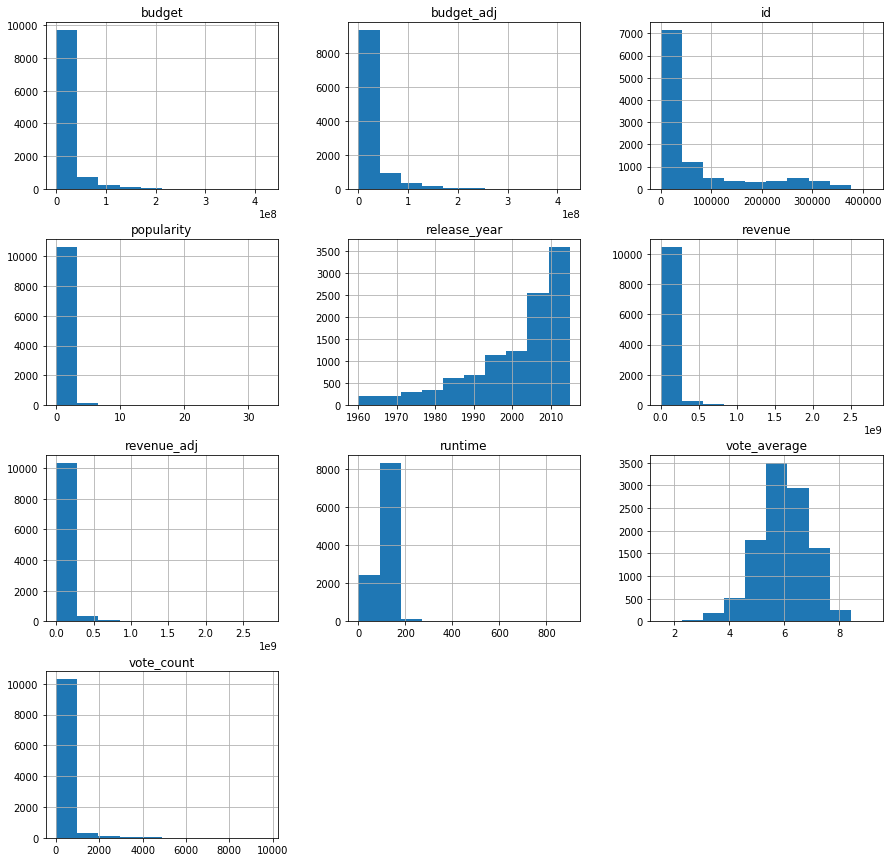

```python
# look at distribution of numerical features
movies.hist(figsize=(15,15))
```

- Many graphs are skewed right (possibly bad data or there are a lot of missing-zero values).
- 'budget', 'revenue', 'runtime', 'budget_adj', and 'revenue_adj' have 0 values. Might be incorrect.
- 'runtime' max of 900 minutes looks unrealistic. This might be a bad data point.
- Only `vote_average` (bell curve) and `release_year` (growth with time) look realistic.

### Data Cleaning

From observing the data, we need to do the following to clean the data:

- Drop duplicate values.
- Fix data points with unrealistic 'runtime', 'revenue', 'budget_adj', and 'revenue_adj'.
- Break data points with multiple 'genre', 'cast', 'keywords', and 'production_companies' into separate values.
- Drop columns we don't need for our analysis.

The first step is to drop duplicated values. We found 1 record that needs to be dropped.

```python
# Drop the duplicated entry
movies.drop_duplicates(inplace=True)
```

```python
# Check that only 1 row was dropped (Expected number of rows is 10865)
movies.shape
```

```
(10865, 21)
```

The next step is to fix data points with unrealistic 'runtime', 'revenue', 'budget_adj', and 'revenue_adj'.

- Runtime should average between 60 to 150 minutes (1 hour to 2.5 hours). It should not be 0, and it likely wouldn't go over 180 minutes (3 hours).
- Revenue, Budget_adj, and Reveune_adj should definitely be greater than 0.

```python
# Look at description for these columns.
movies.loc[:,['runtime', 'revenue','budget_adj','revenue_adj']].describe()
```

|  | runtime | revenue | budget_adj | revenue_adj |
| --- | --- | --- | --- | --- |
| count | 10865.000000 | 1.086500e+04 | 1.086500e+04 | 1.086500e+04 |
| mean | 102.071790 | 3.982690e+07 | 1.754989e+07 | 5.136900e+07 |
| std | 31.382701 | 1.170083e+08 | 3.430753e+07 | 1.446383e+08 |
| min | 0.000000 | 0.000000e+00 | 0.000000e+00 | 0.000000e+00 |
| 25% | 90.000000 | 0.000000e+00 | 0.000000e+00 | 0.000000e+00 |
| 50% | 99.000000 | 0.000000e+00 | 0.000000e+00 | 0.000000e+00 |
| 75% | 111.000000 | 2.400000e+07 | 2.085325e+07 | 3.370173e+07 |
| max | 900.000000 | 2.781506e+09 | 4.250000e+08 | 2.827124e+09 |

We need to fix the 0 values for all field and the 900 minute runtime (looks unrealistic).

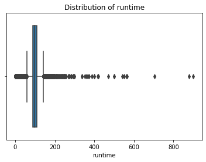

```python
# Identify outliers for runtime
sns.boxplot(x='runtime', data=movies).set_title("Distribution of runtime")
```

```python
movies.query("runtime > 400" ).head()
```

|  | id | imdb_id | popularity | budget | revenue | original_title | cast | homepage | director | tagline | ... | overview | runtime | genres | production_companies | release_date | vote_count | vote_average | release_year | budget_adj | revenue_adj |
| --- | --- | --- | --- | --- | --- | --- | --- | --- | --- | --- | --- | --- | --- | --- | --- | --- | --- | --- | --- | --- | --- |
| 1865 | 220903 | tt1533395 | 0.102223 | 0 | 0 | Life | David Attenborough\|Oprah Winfrey | http://www.bbc.co.uk/programmes/b00lbpcy | Martha Holmes\|Simon Blakeney\|Stephen Lyle | From the Makers of Planet Earth | ... | David Attenborough's legendary BBC crew explai... | 500 | Documentary | British Broadcasting Corporation (BBC) | 12/14/09 | 24 | 7.0 | 2009 | 0.0 | 0.000000e+00 |
| 2170 | 367186 | tt1453159 | 0.082894 | 0 | 0 | The Pillars of the Earth | Ian McShane\|Matthew Macfadyen\|Eddie Redmayne\|H... | NaN | Sergio Mimica-Gezzan | NaN | ... | The Pillars of the Earth is an eight-part 2010... | 421 | Drama\|History\|Romance | Scott Free Productions\|Tandem Communications\|T... | 7/23/10 | 22 | 7.3 | 2010 | 0.0 | 0.000000e+00 |
| 2214 | 189197 | tt0374463 | 0.757082 | 120000000 | 0 | The Pacific | James Badge Dale\|Joseph Mazzello\|Jon Seda\|Asht... | http://www.hbo.com/the-pacific/index.html | Jeremy Podeswa\|Tim Van Patten\|David Nutter\|Gra... | Hell was an ocean away | ... | A 10-part mini-series from the creators of "Ba... | 540 | War\|Drama\|Action\|Adventure\|History | Playtone\|HBO\|DreamWorks Television | 5/16/10 | 183 | 7.8 | 2010 | 120000000.0 | 0.000000e+00 |
| 2722 | 331214 | tt0185906 | 0.537593 | 0 | 125000000 | Band of Brothers | Damian Lewis\|Ron Livingston\|Frank John Hughes\|... | http://www.hbo.com/band-of-brothers | Phil Alden Robinson\|Richard Loncraine\|Mikael S... | Ordinary men. Extraordinary times. | ... | Drawn from interviews with survivors of Easy C... | 705 | Action\|Drama\|War | HBO | 9/9/01 | 313 | 8.0 | 2001 | 0.0 | 1.539360e+08 |
| 3141 | 54102 | tt0995832 | 0.336308 | 0 | 0 | Generation Kill | Alexander SkarsgÃ¥rd\|James Ransone\|Lee Tergese... | NaN | Susanna White\|Simon Cellan Jones | The New Face Of American War | ... | Marines prepare to invade Iraq at the beginnin... | 470 | Drama\|War\|History | Company Pictures | 7/13/08 | 28 | 6.6 | 2008 | 0.0 | 0.000000e+00 |

5 rows × 21 columns

Looking at example data points (imdb_id=tt0185906 'Band of Brothers'), these could also include TV series in which runtime can be a lot greater than an average movie runtime. This means that these data points are actually fine. We only need to fix the movies with a runtime of 0.

For fixing movies with a runtime of 0, we can replace these values with the median. We will not use the mean in this scenario because the distribution of runtime is heavily skewed right.

```python
# Find index of records with runtime = 0
index = movies['runtime'] == 0

# replace those records with median
movies['runtime'][index] = movies.runtime.median()
```

```python
# Check that the min for runtime is no longer 0 minutes.
movies.runtime.describe()
```

```
count    10865.000000
mean       102.354257
std         30.904560
min          2.000000
25%         90.000000
50%         99.000000
75%        111.000000
max        900.000000
Name: runtime, dtype: float64
```

Runtime of 2 minutes is okay because the dataset also includes shorts. For example, 'Bambi Meets Godzilla (1969)' is only 2 minutes long.

Now that we fixed 'runtime', let's also fix 'revenue', 'budget_adj', and 'revenue_adj'.

```python
# Check if we can use median
movies.median()
```

```
id              20662.000000
popularity          0.383831
budget              0.000000
revenue             0.000000
runtime            99.000000
vote_count         38.000000
vote_average        6.000000
release_year     2006.000000
budget_adj          0.000000
revenue_adj         0.000000
dtype: float64
```

```python
# Since all the medians are 0, get the median from the dataset exlucluding the 0 values.
for c in ['budget', 'revenue', 'budget_adj', 'revenue_adj']:
    index = movies[c] != 0
    median = movies[c][index].median()
    index = movies[c] == 0
    movies[c][index] = median

# Check that these values no longer have 0 values
movies.loc[:,['budget', 'revenue', 'budget_adj', 'revenue_adj']].describe()
```

|  | budget | revenue | budget_adj | revenue_adj |
| --- | --- | --- | --- | --- |
| count | 1.086500e+04 | 1.086500e+04 | 1.086500e+04 | 1.086500e+04 |
| mean | 2.353657e+07 | 5.746409e+07 | 2.945831e+07 | 7.570801e+07 |
| std | 2.769628e+07 | 1.119674e+08 | 2.979407e+07 | 1.374663e+08 |
| min | 1.000000e+00 | 2.000000e+00 | 9.210911e-01 | 2.370705e+00 |
| 25% | 1.700000e+07 | 3.185308e+07 | 2.271505e+07 | 4.395666e+07 |
| 50% | 1.700000e+07 | 3.185308e+07 | 2.271505e+07 | 4.395666e+07 |
| 75% | 1.700000e+07 | 3.185308e+07 | 2.271505e+07 | 4.395666e+07 |
| max | 4.250000e+08 | 2.781506e+09 | 4.250000e+08 | 2.827124e+09 |

The next step is to break data points with multiple 'genres', 'cast', 'director', 'keywords', and 'production_companies' into separate values. They are separated by a pipe '|'. We will ignore data entries that have null values.

```python
split_columns = ['genres', 'cast', 'keywords','production_companies','director']

for c in split_columns:
    # Get initial set of pipe rows
    pipe_rows = movies[movies[c].str.contains('|',na=False, regex=False)]
    # Drop the original pipe rows
    movies.drop(pipe_rows.index, inplace=True)
    # Append the rows. Rows are no longer separated by pipe
    while pipe_rows.shape[0] > 0:
        first = pipe_rows.copy()
        second = pipe_rows.copy()
        first[c] = first[c].apply(lambda x: x.split("|",1)[0]) # Get value before first pipe
        movies = movies.append(first)
        second[c] = second[c].apply(lambda x: x.split("|",1)[1]) # Get values(s) after first pipe
        second_nopipe = second[second[c].str.contains('|', regex=False) == False]
        movies = movies.append(second_nopipe)
        second_pipe = second[second[c].str.contains('|', regex=False)]
        pipe_rows = second_pipe
```

```python
# Check that we have removed the delimeters
movies.head()
```

|  | id | imdb_id | popularity | budget | revenue | original_title | cast | homepage | director | tagline | ... | overview | runtime | genres | production_companies | release_date | vote_count | vote_average | release_year | budget_adj | revenue_adj |
| --- | --- | --- | --- | --- | --- | --- | --- | --- | --- | --- | --- | --- | --- | --- | --- | --- | --- | --- | --- | --- | --- |
| 371 | 345637 | tt4661600 | 0.422901 | 17000000 | 31853080 | Sanjay's Super Team | NaN | NaN | Sanjay Patel | NaN | ... | Sanjay's Super Team follows the daydream of a ... | 7 | Animation | Pixar Animation Studios | 11/25/15 | 47 | 6.9 | 2015 | 2.271505e+07 | 4.395666e+07 |
| 567 | 348035 | tt4835636 | 0.090045 | 17000000 | 31853080 | Chris Tucker: Live | Chris Tucker | NaN | Phil Joanou | It's Been a Long Time Coming. | ... | Comedian Chris Tucker performs live. | 92 | Comedy | NetFlix | 7/10/15 | 19 | 6.7 | 2015 | 2.271505e+07 | 4.395666e+07 |
| 576 | 326665 | tt4530184 | 0.081820 | 17000000 | 31853080 | Aziz Ansari: Live at Madison Square Garden | Aziz Ansari | http://www.netflix.com/WiMovie/80038296 | Aziz Ansari | NaN | ... | Ansari headlines the iconic Madison Square Gar... | 58 | Comedy | NaN | 3/6/15 | 35 | 7.1 | 2015 | 2.271505e+07 | 4.395666e+07 |
| 587 | 319091 | tt4185572 | 0.062536 | 17000000 | 31853080 | The Hunting Ground | NaN | NaN | Kirby Dick | NaN | ... | From the makers of The Invisible War comes a s... | 103 | Documentary | NaN | 2/27/15 | 39 | 7.8 | 2015 | 2.271505e+07 | 4.395666e+07 |
| 612 | 325365 | tt1421361 | 0.030819 | 17000000 | 31853080 | Dawg Fight | Dhafir Harris | http://www.dawg-fight.com | Billy Corben | NaN | ... | In a crime-plagued neighborhood near Miami, br... | 109 | Documentary | Rakontur | 3/13/15 | 17 | 6.4 | 2015 | 2.271505e+07 | 4.395666e+07 |

5 rows × 21 columns

Last thing to do is to remove the columns we won't use for our analysis. This step isn't necessary and is not recommended when we don't know whether we will use the columns later on. However, for this assignment we are certain that we will not use 'imdb_id', 'homepage', 'tagline', and 'overview'.

```python
movies.drop(columns = ['imdb_id', 'homepage', 'tagline', 'overview'], inplace = True)
movies.head(1)
```

|  | id | popularity | budget | revenue | original_title | cast | director | keywords | runtime | genres | production_companies | release_date | vote_count | vote_average | release_year | budget_adj | revenue_adj |
| --- | --- | --- | --- | --- | --- | --- | --- | --- | --- | --- | --- | --- | --- | --- | --- | --- | --- |
| 371 | 345637 | 0.422901 | 17000000 | 31853080 | Sanjay's Super Team | NaN | Sanjay Patel | NaN | 7 | Animation | Pixar Animation Studios | 11/25/15 | 47 | 6.9 | 2015 | 2.271505e+07 | 4.395666e+07 |

## Exploratory Data Analysis

### Do movies get a higher vote if they are lead by a particular director?

To see how directors influence ratings, we can first see the distribution of average votes among directors.

```python
# Get average stats by director (first get it by director+movie ID because rows have been expanded earlier)
director_movies = movies.groupby(['director', 'id']).mean()
director_movies = director_movies.groupby('director').mean()

# Sort directors based on average vote
director_movies.sort_values(by=['vote_average'], inplace=True)

# Who are the top 10 directors with highly rated movies?
director_movies.vote_average.tail(10)
```

```
director
Chris Hegedus           8.4
David Dawkins           8.4
Anthony Mandler         8.4
Curt Morgan             8.5
Michael Henry Wilson    8.5
James Payne             8.5
Saul Swimmer            8.5
David Mallet            8.7
Derek Frankowski        8.8
Mark Cousins            9.2
Name: vote_average, dtype: float64
```

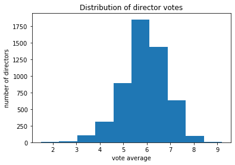

```python
# What is the distribution of votes by director?
# director_movies.vote_average.hist()
plt.hist(x=director_movies.vote_average)
plt.title('Distribution of director votes')
plt.xlabel('vote average')
plt.ylabel('number of directors')
```

The bell-curve distribution of average votes for directors has a median and average around 6.0. So there are some directors who create movies with higher votes than others.

Let's see what else can influence higher votes. Does budget affect rating?

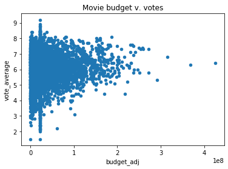

```python
movie = movies.groupby(['id']).mean()
movie.plot(kind='scatter',x='budget_adj',y='vote_average', title='Movie budget v. votes')
```

The scatterplot has a very weak correlation between adjusted budget and average vote. If the budget is below $100,000,000 then the votes can be anything across the spectrum. As the budget increases, votes are less likely to receive a low rating.

```python
# Check the correlations to confirm that budget and vote are very weakly (positively) correlated.
movie.corr()
```

|  | popularity | budget | revenue | runtime | vote_count | vote_average | release_year | budget_adj | revenue_adj |
| --- | --- | --- | --- | --- | --- | --- | --- | --- | --- |
| popularity | 1.000000 | 0.507850 | 0.642605 | 0.136979 | 0.800828 | 0.209517 | 0.089806 | 0.465888 | 0.583965 |
| budget | 0.507850 | 1.000000 | 0.708057 | 0.166771 | 0.609206 | 0.072592 | 0.130983 | 0.961486 | 0.574073 |
| revenue | 0.642605 | 0.708057 | 1.000000 | 0.146477 | 0.778513 | 0.156685 | 0.063624 | 0.674822 | 0.911229 |
| runtime | 0.136979 | 0.166771 | 0.146477 | 1.000000 | 0.162678 | 0.154691 | -0.112372 | 0.196971 | 0.158351 |
| vote_count | 0.800828 | 0.609206 | 0.778513 | 0.162678 | 1.000000 | 0.253818 | 0.107962 | 0.555477 | 0.690607 |
| vote_average | 0.209517 | 0.072592 | 0.156685 | 0.154691 | 0.253818 | 1.000000 | -0.117576 | 0.084954 | 0.176581 |
| release_year | 0.089806 | 0.130983 | 0.063624 | -0.112372 | 0.107962 | -0.117576 | 1.000000 | 0.021314 | -0.065214 |
| budget_adj | 0.465888 | 0.961486 | 0.674822 | 0.196971 | 0.555477 | 0.084954 | 0.021314 | 1.000000 | 0.599660 |
| revenue_adj | 0.583965 | 0.574073 | 0.911229 | 0.158351 | 0.690607 | 0.176581 | -0.065214 | 0.599660 | 1.000000 |

The correlation between budget(adjusted) and average vote is 0.08, which is not very impactful. Looking at the other metrics, there are not a lot strongly correlated with average vote.

### How has popularity for movies increased over time? How does it differ by genre?

For the first question, we will plot average popularity over time.

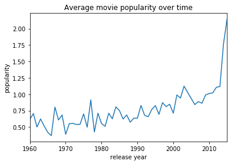

```python
# Get average popularity per year
year_pop = movies.groupby(['release_year']).mean().popularity

# Make a line plot
x = year_pop.plot.line(title="Average movie popularity over time", x = "release_year", y = "popularity")
x.set_xlabel("release year")
x.set_ylabel("popularity")
```

From the above graph, we observe the following:

- We can see that popularity for all movies have increased over time.
- Overall popularity is below 1 from 1960s to 2000s.
- In the early 2000s, popularity for movies have increased dramatically. Popularity lingers between .80 and 1.20 from 2000 to 2010. Popularity goes from 1 to 2 after 2010.

The graph is a little noisy, so let's smoothen it using moving averages.

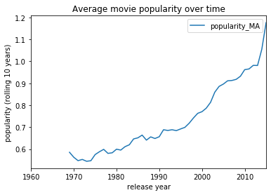

```python
# Turn popularity into moving average
year_pop_df = year_pop.to_frame()
year_pop_df['popularity_MA'] = year_pop_df['popularity'].rolling(window=10).mean()
year_pop_df.reset_index(inplace=True)

x = year_pop_df.plot.line(title="Average movie popularity over time", x = "release_year", y = "popularity_MA")
x.set_xlabel("release year")
x.set_ylabel("popularity (rolling 10 years)")
```

This smoothened graph shows that popularity has been increasing at an exponential rate. Let's see how it breaks by genre.

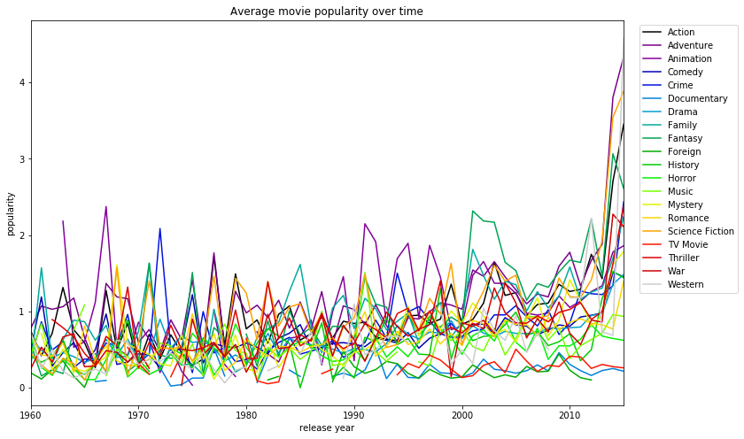

```python
# Plot average popularity over time separated by genres
year_pop_genres = movies.groupby(['release_year', 'genres']).mean().popularity.unstack()
genres_plot = year_pop_genres.plot.line(title="Average movie popularity over time", figsize=(12,8), colormap = 'nipy_spectral')
genres_plot.legend(loc='upper right', bbox_to_anchor=(1.2, 1))
genres_plot.set_xlabel("release year")
genres_plot.set_ylabel("popularity")

# Alternative plot using seaborn library
# x = sns.lineplot(data=p, hue = 'genres', dashes=False)
# sns.lineplot(x='release_year', y='populatrity', hue='genres', data = movies)
```

We notice that after 2010, while the overall average popularity reached a score of 2.0, many genres surpass that score. These genres include Science Fiction, Western, Action, and Adventure.

However, the graph is really noisy so let's smoothen it out too.

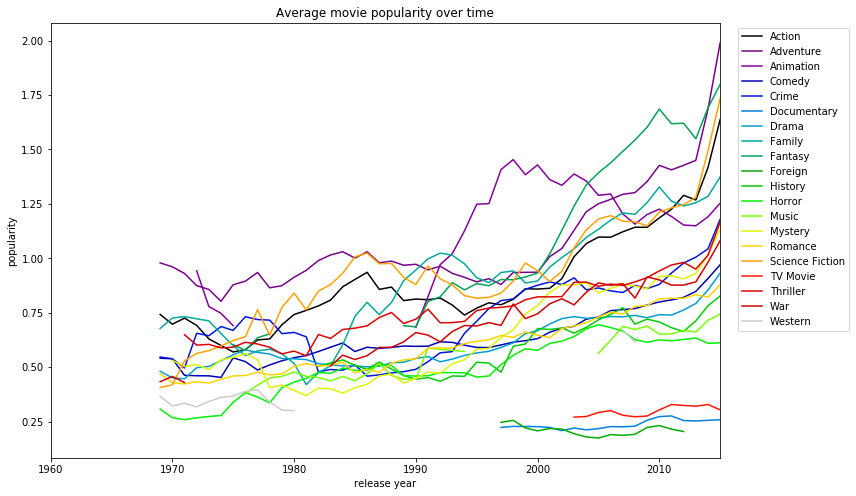

```python
# Convert dataframe to show average popularity in rolling 10 years
year_pop_genres_df = year_pop_genres.copy()

for c in year_pop_genres_df.columns:
    year_pop_genres_df[c] = year_pop_genres_df[c].rolling(window=10).mean()

# Plot graph
# Colormap options are here https://matplotlib.org/users/colormaps.html
genres_plot_df = year_pop_genres_df.plot.line(title="Average movie popularity over time", figsize=(12,8), colormap = 'nipy_spectral')
genres_plot_df.legend(loc='upper right', bbox_to_anchor=(1.2, 1))
genres_plot_df.set_xlabel("release year")
genres_plot_df.set_ylabel("popularity")
```

From the above graph, we observe the following:

- TV Movie, Documentary, and Foreign remain relatively unpopular in the 2000s, as their average popularity stays below 0.5.
- Animation was leading in average popularity between 1.25 and 1.5 from 1995 to 2000s. Animation was actually above the overall average until the 2000s.
- Fantasy was the most popular in the 2000s. This is better seen in the graph with noise.

### What influences higher revenue in movies?

```python
# Look at the table of correlation again
movie.corr()
```

|  | popularity | budget | revenue | runtime | vote_count | vote_average | release_year | budget_adj | revenue_adj |
| --- | --- | --- | --- | --- | --- | --- | --- | --- | --- |
| popularity | 1.000000 | 0.507850 | 0.642605 | 0.136979 | 0.800828 | 0.209517 | 0.089806 | 0.465888 | 0.583965 |
| budget | 0.507850 | 1.000000 | 0.708057 | 0.166771 | 0.609206 | 0.072592 | 0.130983 | 0.961486 | 0.574073 |
| revenue | 0.642605 | 0.708057 | 1.000000 | 0.146477 | 0.778513 | 0.156685 | 0.063624 | 0.674822 | 0.911229 |
| runtime | 0.136979 | 0.166771 | 0.146477 | 1.000000 | 0.162678 | 0.154691 | -0.112372 | 0.196971 | 0.158351 |
| vote_count | 0.800828 | 0.609206 | 0.778513 | 0.162678 | 1.000000 | 0.253818 | 0.107962 | 0.555477 | 0.690607 |
| vote_average | 0.209517 | 0.072592 | 0.156685 | 0.154691 | 0.253818 | 1.000000 | -0.117576 | 0.084954 | 0.176581 |
| release_year | 0.089806 | 0.130983 | 0.063624 | -0.112372 | 0.107962 | -0.117576 | 1.000000 | 0.021314 | -0.065214 |
| budget_adj | 0.465888 | 0.961486 | 0.674822 | 0.196971 | 0.555477 | 0.084954 | 0.021314 | 1.000000 | 0.599660 |
| revenue_adj | 0.583965 | 0.574073 | 0.911229 | 0.158351 | 0.690607 | 0.176581 | -0.065214 | 0.599660 | 1.000000 |

Revenue is positively correlated with budget, vote_count, and popularity. It is not very correlated with vote_average or release_year.

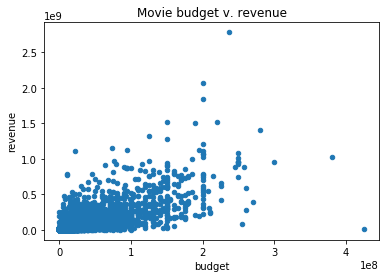

```python
movie.plot(kind='scatter', x='budget', y='revenue', title ='Movie budget v. revenue')
```

This graph shows that it is positively correlated.

## Conclusions

In the data wrangling section, we dealt with movies with multiple directors, production companies, and genres. We also learned that the dataset includes not only movies but also shorts and TV Series (indicated by runtime and cross-referencing specific titles on the Internet).

In the data exploration section, we learned that movie ratings on a sale of 1 to 10 could vary by director, as there are some directors like Mark Cousins or David Mallet who average above 8. However, ratings aren't strongly influenced by budget or runtime. We also learned that popularity of movies and entertainment have increased over time. They can vary by genre, too. For example, Fantasy have increased significantly in the 2000s, but Horror has not increased as dramatically in popularity. Lastly, we observe that higher revenue is correlated with higher budget and popularity.